# Risk Factor Analysis

## Outcome Variable

**Outcome Variable:** wasted

## Predictor Variables

**Intervention Variable:** predfeed6

**Adjustment Set:**

- arm
- sex
- month
- brthmon
- W_mage
- meducyrs
- feducyrs
- hhwealth_quart
- hfoodsec
- W_mhtcm
- W_mwtkg
- W_mbmi
- vagbrth
- W_gagebrth
- W_birthwt
- W_birthlen
- W_nrooms
- W_nchldlt5
- W_parity
- impfloor
- impsan
- safeh20
- delta_W_mage
- delta_meducyrs
- delta_feducyrs
- delta_hhwealth_quart
- delta_hfoodsec
- delta_W_mhtcm
- delta_W_mwtkg
- delta_W_mbmi
- delta_vagbrth
- delta_W_gagebrth
- delta_W_birthwt
- delta_W_birthlen
- delta_W_nrooms
- delta_W_nchldlt5
- delta_W_parity
- delta_impfloor
- delta_impsan
- delta_safeh20

## Stratifying Variables

The analysis was stratified on these variable(s):

- agecat
- studyid
- country

## Data Summary

| agecat | studyid | country | predfeed6 | wasted | n_cell | n |
| --- | --- | --- | --- | --- | --- | --- |
| Birth | EE | PAKISTAN | 1 | 0 | 20 | 28 |
| Birth | EE | PAKISTAN | 1 | 1 | 4 | 28 |
| Birth | EE | PAKISTAN | 0 | 0 | 3 | 28 |
| Birth | EE | PAKISTAN | 0 | 1 | 1 | 28 |
| Birth | GMS-Nepal | NEPAL | 1 | 0 | 309 | 522 |
| Birth | GMS-Nepal | NEPAL | 1 | 1 | 81 | 522 |
| Birth | GMS-Nepal | NEPAL | 0 | 0 | 111 | 522 |
| Birth | GMS-Nepal | NEPAL | 0 | 1 | 21 | 522 |
| Birth | JiVitA-3 | BANGLADESH | 1 | 0 | 7437 | 10744 |
| Birth | JiVitA-3 | BANGLADESH | 1 | 1 | 955 | 10744 |
| Birth | JiVitA-3 | BANGLADESH | 0 | 0 | 2112 | 10744 |
| Birth | JiVitA-3 | BANGLADESH | 0 | 1 | 240 | 10744 |
| Birth | JiVitA-4 | BANGLADESH | 1 | 0 | 1626 | 2224 |
| Birth | JiVitA-4 | BANGLADESH | 1 | 1 | 176 | 2224 |
| Birth | JiVitA-4 | BANGLADESH | 0 | 0 | 375 | 2224 |
| Birth | JiVitA-4 | BANGLADESH | 0 | 1 | 47 | 2224 |
| Birth | MAL-ED | BANGLADESH | 1 | 0 | 58 | 194 |
| Birth | MAL-ED | BANGLADESH | 1 | 1 | 10 | 194 |
| Birth | MAL-ED | BANGLADESH | 0 | 0 | 102 | 194 |
| Birth | MAL-ED | BANGLADESH | 0 | 1 | 24 | 194 |
| Birth | MAL-ED | BRAZIL | 1 | 0 | 5 | 57 |
| Birth | MAL-ED | BRAZIL | 1 | 1 | 0 | 57 |
| Birth | MAL-ED | BRAZIL | 0 | 0 | 50 | 57 |
| Birth | MAL-ED | BRAZIL | 0 | 1 | 2 | 57 |
| Birth | MAL-ED | INDIA | 1 | 0 | 4 | 37 |
| Birth | MAL-ED | INDIA | 1 | 1 | 0 | 37 |
| Birth | MAL-ED | INDIA | 0 | 0 | 28 | 37 |
| Birth | MAL-ED | INDIA | 0 | 1 | 5 | 37 |
| Birth | MAL-ED | NEPAL | 1 | 0 | 3 | 23 |
| Birth | MAL-ED | NEPAL | 1 | 1 | 0 | 23 |

[output cut: 114 more lines]

The following strata were considered:

- agecat: 24 months, studyid: EE, country: PAKISTAN
- agecat: 24 months, studyid: GMS-Nepal, country: NEPAL
- agecat: 24 months, studyid: JiVitA-3, country: BANGLADESH
- agecat: 24 months, studyid: JiVitA-4, country: BANGLADESH
- agecat: 24 months, studyid: LCNI-5, country: MALAWI
- agecat: 24 months, studyid: MAL-ED, country: BANGLADESH
- agecat: 24 months, studyid: MAL-ED, country: BRAZIL
- agecat: 24 months, studyid: MAL-ED, country: INDIA
- agecat: 24 months, studyid: MAL-ED, country: NEPAL
- agecat: 24 months, studyid: MAL-ED, country: PERU
- agecat: 24 months, studyid: MAL-ED, country: SOUTH AFRICA
- agecat: 24 months, studyid: MAL-ED, country: TANZANIA, UNITED REPUBLIC OF
- agecat: 6 months, studyid: EE, country: PAKISTAN
- agecat: 6 months, studyid: GMS-Nepal, country: NEPAL
- agecat: 6 months, studyid: JiVitA-3, country: BANGLADESH
- agecat: 6 months, studyid: JiVitA-4, country: BANGLADESH
- agecat: 6 months, studyid: LCNI-5, country: MALAWI
- agecat: 6 months, studyid: MAL-ED, country: BANGLADESH
- agecat: 6 months, studyid: MAL-ED, country: BRAZIL
- agecat: 6 months, studyid: MAL-ED, country: INDIA
- agecat: 6 months, studyid: MAL-ED, country: NEPAL
- agecat: 6 months, studyid: MAL-ED, country: PERU
- agecat: 6 months, studyid: MAL-ED, country: SOUTH AFRICA
- agecat: 6 months, studyid: MAL-ED, country: TANZANIA, UNITED REPUBLIC OF
- agecat: 6 months, studyid: SAS-FoodSuppl, country: INDIA
- agecat: Birth, studyid: EE, country: PAKISTAN
- agecat: Birth, studyid: GMS-Nepal, country: NEPAL
- agecat: Birth, studyid: JiVitA-3, country: BANGLADESH
- agecat: Birth, studyid: JiVitA-4, country: BANGLADESH
- agecat: Birth, studyid: MAL-ED, country: BANGLADESH
- agecat: Birth, studyid: MAL-ED, country: BRAZIL
- agecat: Birth, studyid: MAL-ED, country: INDIA
- agecat: Birth, studyid: MAL-ED, country: NEPAL
- agecat: Birth, studyid: MAL-ED, country: PERU
- agecat: Birth, studyid: MAL-ED, country: SOUTH AFRICA
- agecat: Birth, studyid: MAL-ED, country: TANZANIA, UNITED REPUBLIC OF

### Dropped Strata

Some strata were dropped due to rare outcomes:

- agecat: Birth, studyid: EE, country: PAKISTAN
- agecat: Birth, studyid: MAL-ED, country: BRAZIL
- agecat: Birth, studyid: MAL-ED, country: INDIA
- agecat: Birth, studyid: MAL-ED, country: NEPAL
- agecat: Birth, studyid: MAL-ED, country: PERU
- agecat: Birth, studyid: MAL-ED, country: SOUTH AFRICA
- agecat: Birth, studyid: MAL-ED, country: TANZANIA, UNITED REPUBLIC OF
- agecat: 6 months, studyid: EE, country: PAKISTAN
- agecat: 6 months, studyid: LCNI-5, country: MALAWI
- agecat: 6 months, studyid: MAL-ED, country: BANGLADESH
- agecat: 6 months, studyid: MAL-ED, country: BRAZIL
- agecat: 6 months, studyid: MAL-ED, country: INDIA
- agecat: 6 months, studyid: MAL-ED, country: NEPAL
- agecat: 6 months, studyid: MAL-ED, country: PERU
- agecat: 6 months, studyid: MAL-ED, country: SOUTH AFRICA
- agecat: 6 months, studyid: MAL-ED, country: TANZANIA, UNITED REPUBLIC OF
- agecat: 6 months, studyid: SAS-FoodSuppl, country: INDIA
- agecat: 24 months, studyid: EE, country: PAKISTAN
- agecat: 24 months, studyid: LCNI-5, country: MALAWI
- agecat: 24 months, studyid: MAL-ED, country: BRAZIL
- agecat: 24 months, studyid: MAL-ED, country: INDIA
- agecat: 24 months, studyid: MAL-ED, country: NEPAL
- agecat: 24 months, studyid: MAL-ED, country: PERU
- agecat: 24 months, studyid: MAL-ED, country: SOUTH AFRICA
- agecat: 24 months, studyid: MAL-ED, country: TANZANIA, UNITED REPUBLIC OF

## Methods Detail

We’re interested in the causal parameters $E[Y_a]$ for all values of $a \in \mathcal{A}$. These parameters represent the mean outcome if, possibly contrary to fact, we intervened to set all units to have $A=a$. Under the randomization and positivity assumptions, these are identified by the statistical parameters $\psi_a=E_W[E_{Y|A,W}(Y|A=a,W)]$. In addition, we’re interested in the mean of $Y$, $E[Y]$ under no intervention (the observed mean). We will estimate these parameters by using SuperLearner to fit the relevant likelihood factors – $E_{Y|A,W}(Y|A=a,W)$ and $p(A=a|W)$, and then updating our likelihood fit using a joint TMLE.

For unadjusted analyses ($W=\{\}$), initial likelihoods were estimated using Lrnr_glm to estimate the simple $E(Y|A)$ and Lrnr_mean to estimate $p(A)$. For adjusted analyses, a small library containing Lrnr_glmnet, Lrnr_xgboost, and Lrnr_mean was used.

Having estimated these parameters, we will then use the delta method to estimate relative risks and attributable risks relative to a prespecified baseline level of $A$.

# Results Detail

## Results Plots

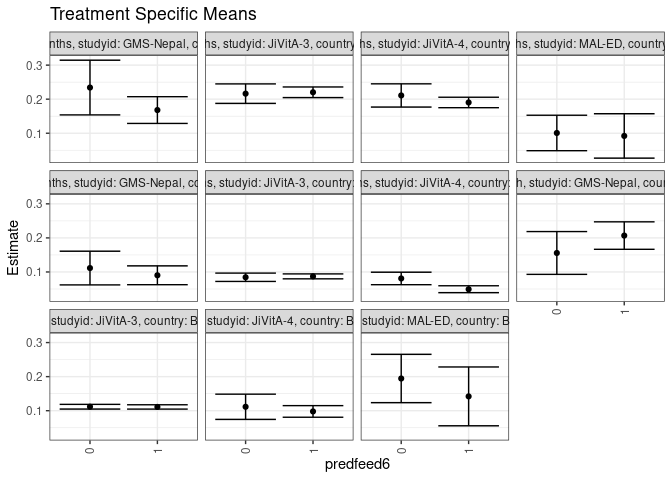

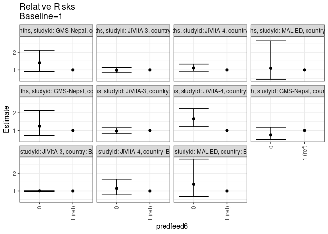

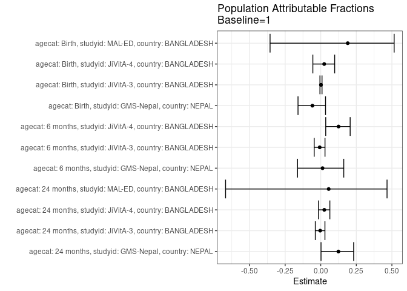

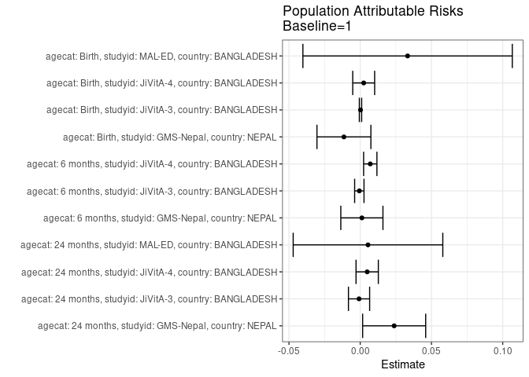

## Results Table

### Parameter: TSM

| agecat | studyid | country | intervention_level | baseline_level | estimate | ci_lower | ci_upper |
| --- | --- | --- | --- | --- | --- | --- | --- |
| Birth | GMS-Nepal | NEPAL | 1 | NA | 0.2068436 | 0.1665099 | 0.2471773 |
| Birth | GMS-Nepal | NEPAL | 0 | NA | 0.1557443 | 0.0929286 | 0.2185601 |
| Birth | JiVitA-3 | BANGLADESH | 1 | NA | 0.1110292 | 0.1046451 | 0.1174133 |
| Birth | JiVitA-3 | BANGLADESH | 0 | NA | 0.1116494 | 0.1047689 | 0.1185300 |
| Birth | JiVitA-4 | BANGLADESH | 1 | NA | 0.0978340 | 0.0808335 | 0.1148345 |
| Birth | JiVitA-4 | BANGLADESH | 0 | NA | 0.1114411 | 0.0744391 | 0.1484431 |
| Birth | MAL-ED | BANGLADESH | 1 | NA | 0.1420087 | 0.0556523 | 0.2283651 |
| Birth | MAL-ED | BANGLADESH | 0 | NA | 0.1944939 | 0.1235582 | 0.2654296 |
| 6 months | GMS-Nepal | NEPAL | 1 | NA | 0.0902451 | 0.0625724 | 0.1179177 |
| 6 months | GMS-Nepal | NEPAL | 0 | NA | 0.1114716 | 0.0620086 | 0.1609346 |
| 6 months | JiVitA-3 | BANGLADESH | 1 | NA | 0.0870507 | 0.0797814 | 0.0943200 |
| 6 months | JiVitA-3 | BANGLADESH | 0 | NA | 0.0844354 | 0.0721712 | 0.0966996 |
| 6 months | JiVitA-4 | BANGLADESH | 1 | NA | 0.0493202 | 0.0392005 | 0.0594399 |
| 6 months | JiVitA-4 | BANGLADESH | 0 | NA | 0.0809280 | 0.0625613 | 0.0992948 |
| 24 months | GMS-Nepal | NEPAL | 1 | NA | 0.1680783 | 0.1288040 | 0.2073525 |
| 24 months | GMS-Nepal | NEPAL | 0 | NA | 0.2341730 | 0.1538833 | 0.3144628 |
| 24 months | JiVitA-3 | BANGLADESH | 1 | NA | 0.2202850 | 0.2046637 | 0.2359062 |
| 24 months | JiVitA-3 | BANGLADESH | 0 | NA | 0.2162435 | 0.1876193 | 0.2448676 |
| 24 months | JiVitA-4 | BANGLADESH | 1 | NA | 0.1903788 | 0.1750308 | 0.2057268 |
| 24 months | JiVitA-4 | BANGLADESH | 0 | NA | 0.2109695 | 0.1768477 | 0.2450914 |
| 24 months | MAL-ED | BANGLADESH | 1 | NA | 0.0921053 | 0.0269330 | 0.1572776 |
| 24 months | MAL-ED | BANGLADESH | 0 | NA | 0.1007752 | 0.0487006 | 0.1528498 |

### Parameter: E(Y)

| agecat | studyid | country | intervention_level | baseline_level | estimate | ci_lower | ci_upper |
| --- | --- | --- | --- | --- | --- | --- | --- |
| Birth | GMS-Nepal | NEPAL | NA | NA | 0.1954023 | 0.1613549 | 0.2294497 |
| Birth | JiVitA-3 | BANGLADESH | NA | NA | 0.1112249 | 0.1049045 | 0.1175452 |
| Birth | JiVitA-4 | BANGLADESH | NA | NA | 0.1002698 | 0.0846581 | 0.1158815 |
| Birth | MAL-ED | BANGLADESH | NA | NA | 0.1752577 | 0.1216204 | 0.2288951 |
| 6 months | GMS-Nepal | NEPAL | NA | NA | 0.0914077 | 0.0672348 | 0.1155805 |
| 6 months | JiVitA-3 | BANGLADESH | NA | NA | 0.0864198 | 0.0802086 | 0.0926309 |
| 6 months | JiVitA-4 | BANGLADESH | NA | NA | 0.0563743 | 0.0475411 | 0.0652074 |
| 24 months | GMS-Nepal | NEPAL | NA | NA | 0.1918977 | 0.1562203 | 0.2275751 |
| 24 months | JiVitA-3 | BANGLADESH | NA | NA | 0.2194592 | 0.2057462 | 0.2331723 |
| 24 months | JiVitA-4 | BANGLADESH | NA | NA | 0.1952677 | 0.1809764 | 0.2095589 |
| 24 months | MAL-ED | BANGLADESH | NA | NA | 0.0975610 | 0.0568436 | 0.1382784 |

### Parameter: RR

| agecat | studyid | country | intervention_level | baseline_level | estimate | ci_lower | ci_upper |
| --- | --- | --- | --- | --- | --- | --- | --- |
| Birth | GMS-Nepal | NEPAL | 1 | 1 | 1.0000000 | 1.0000000 | 1.000000 |
| Birth | GMS-Nepal | NEPAL | 0 | 1 | 0.7529571 | 0.4810164 | 1.178638 |
| Birth | JiVitA-3 | BANGLADESH | 1 | 1 | 1.0000000 | 1.0000000 | 1.000000 |
| Birth | JiVitA-3 | BANGLADESH | 0 | 1 | 1.0055862 | 0.9729724 | 1.039293 |
| Birth | JiVitA-4 | BANGLADESH | 1 | 1 | 1.0000000 | 1.0000000 | 1.000000 |
| Birth | JiVitA-4 | BANGLADESH | 0 | 1 | 1.1390838 | 0.7853786 | 1.652085 |
| Birth | MAL-ED | BANGLADESH | 1 | 1 | 1.0000000 | 1.0000000 | 1.000000 |
| Birth | MAL-ED | BANGLADESH | 0 | 1 | 1.3695918 | 0.6733283 | 2.785836 |
| 6 months | GMS-Nepal | NEPAL | 1 | 1 | 1.0000000 | 1.0000000 | 1.000000 |
| 6 months | GMS-Nepal | NEPAL | 0 | 1 | 1.2352103 | 0.7192879 | 2.121187 |
| 6 months | JiVitA-3 | BANGLADESH | 1 | 1 | 1.0000000 | 1.0000000 | 1.000000 |
| 6 months | JiVitA-3 | BANGLADESH | 0 | 1 | 0.9699573 | 0.8189222 | 1.148848 |
| 6 months | JiVitA-4 | BANGLADESH | 1 | 1 | 1.0000000 | 1.0000000 | 1.000000 |
| 6 months | JiVitA-4 | BANGLADESH | 0 | 1 | 1.6408698 | 1.2078326 | 2.229161 |
| 24 months | GMS-Nepal | NEPAL | 1 | 1 | 1.0000000 | 1.0000000 | 1.000000 |
| 24 months | GMS-Nepal | NEPAL | 0 | 1 | 1.3932381 | 0.9197947 | 2.110376 |
| 24 months | JiVitA-3 | BANGLADESH | 1 | 1 | 1.0000000 | 1.0000000 | 1.000000 |
| 24 months | JiVitA-3 | BANGLADESH | 0 | 1 | 0.9816534 | 0.8448347 | 1.140629 |
| 24 months | JiVitA-4 | BANGLADESH | 1 | 1 | 1.0000000 | 1.0000000 | 1.000000 |
| 24 months | JiVitA-4 | BANGLADESH | 0 | 1 | 1.1081568 | 0.9286887 | 1.322307 |
| 24 months | MAL-ED | BANGLADESH | 1 | 1 | 1.0000000 | 1.0000000 | 1.000000 |
| 24 months | MAL-ED | BANGLADESH | 0 | 1 | 1.0941307 | 0.4555621 | 2.627791 |

### Parameter: PAR

| agecat | studyid | country | intervention_level | baseline_level | estimate | ci_lower | ci_upper |
| --- | --- | --- | --- | --- | --- | --- | --- |
| Birth | GMS-Nepal | NEPAL | 1 | NA | -0.0114413 | -0.0303705 | 0.0074879 |
| Birth | JiVitA-3 | BANGLADESH | 1 | NA | 0.0001957 | -0.0006197 | 0.0010111 |
| Birth | JiVitA-4 | BANGLADESH | 1 | NA | 0.0024358 | -0.0052570 | 0.0101285 |
| Birth | MAL-ED | BANGLADESH | 1 | NA | 0.0332491 | -0.0402323 | 0.1067305 |
| 6 months | GMS-Nepal | NEPAL | 1 | NA | 0.0011626 | -0.0136249 | 0.0159501 |
| 6 months | JiVitA-3 | BANGLADESH | 1 | NA | -0.0006309 | -0.0039195 | 0.0026576 |
| 6 months | JiVitA-4 | BANGLADESH | 1 | NA | 0.0070541 | 0.0023856 | 0.0117226 |
| 24 months | GMS-Nepal | NEPAL | 1 | NA | 0.0238194 | 0.0016978 | 0.0459410 |
| 24 months | JiVitA-3 | BANGLADESH | 1 | NA | -0.0008257 | -0.0082603 | 0.0066088 |
| 24 months | JiVitA-4 | BANGLADESH | 1 | NA | 0.0048889 | -0.0029349 | 0.0127128 |
| 24 months | MAL-ED | BANGLADESH | 1 | NA | 0.0054557 | -0.0470421 | 0.0579535 |

### Parameter: PAF

| agecat | studyid | country | intervention_level | baseline_level | estimate | ci_lower | ci_upper |
| --- | --- | --- | --- | --- | --- | --- | --- |
| Birth | GMS-Nepal | NEPAL | 1 | NA | -0.0585525 | -0.1596368 | 0.0337204 |
| Birth | JiVitA-3 | BANGLADESH | 1 | NA | 0.0017593 | -0.0056009 | 0.0090657 |
| Birth | JiVitA-4 | BANGLADESH | 1 | NA | 0.0242922 | -0.0553896 | 0.0979581 |
| Birth | MAL-ED | BANGLADESH | 1 | NA | 0.1897153 | -0.3560602 | 0.5158317 |
| 6 months | GMS-Nepal | NEPAL | 1 | NA | 0.0127191 | -0.1628996 | 0.1618162 |
| 6 months | JiVitA-3 | BANGLADESH | 1 | NA | -0.0073008 | -0.0460395 | 0.0300034 |
| 6 months | JiVitA-4 | BANGLADESH | 1 | NA | 0.1251294 | 0.0350924 | 0.2067648 |
| 24 months | GMS-Nepal | NEPAL | 1 | NA | 0.1241255 | 0.0019511 | 0.2313441 |
| 24 months | JiVitA-3 | BANGLADESH | 1 | NA | -0.0037625 | -0.0382174 | 0.0295489 |
| 24 months | JiVitA-4 | BANGLADESH | 1 | NA | 0.0250371 | -0.0156530 | 0.0640969 |
| 24 months | MAL-ED | BANGLADESH | 1 | NA | 0.0559211 | -0.6686320 | 0.4658588 |